# VL14: Rückblick, LV-Umfrage, Klausurvorbereitung

IFM 5.6 Künstliche Intelligenz, 2017/18

Carsten Gips, FH Bielefeld

# Rückblick

## Ausgangspunkt: Was ist Intelligenz

[figure not shown]

Quelle: [wikipedia.de](http://upload.wikimedia.org/wikipedia/en/0/09/DataTNG.jpg)

[figure not shown]

Quelle: [wikipedia.de](http://upload.wikimedia.org/wikipedia/en/3/39/R2-D2_Droid.png)

## Definitionsversuche und Sichtweisen

> Artificial Intelligence is the study of how to make computers do things at which, at the moment, people are better.

> – Elaine Rich (“Artificial Intelligence”, McGraw-Hill, 1983)
- Verhalten vs. Denken
  - “schwache KI”: intelligent **wirkende** Maschinen
  - “starke KI”: **denkende** Maschinen
- Menschliches Vorbild vs. rein rational

=> Möglichst breiter Überblick über Methoden

=> Motivation: Wie funktioniert … beispielsweise das Gehirn?

### Themen

1. Problemlösen
   - Zustände, Aktionen, Problemraum
   - Suche (blind, informiert): Breiten-, Tiefensuche, Best-First, Branch-and-Bound, A-Stern
   - Lokale Suche: Gradientenabstieg, Genetische/Evolutionäre Algorithmen (GA/EA)
   - Spiele: Minimax, Alpha-Beta-Pruning, Heuristiken
   - Constraints: Backtracking, Heuristiken, Propagation, AC-3
2. Maschinelles Lernen
   - Merkmalsvektor, Trainingsmenge, Trainingsfehler, Generalisierung
   - Entscheidungsbäume: CAL2, CAL3, ID3
   - Neuronale Netze
     - Perzeptron, Lernregel
     - Feedforward Multilayer Perzeptron (MLP), Backpropagation, Trainings- vs. Generalisierungsfehler
     - Steuerung des Trainings: Crossvalidierung, Regularisierung
     - Ausblick: Support-Vektor-Maschinen
   - Naive Bayes Klassifikator[^1]
3. Inferenz, Logik
   - Prädikatenlogik: Modellierung, semantische und formale Beweise, Unifikation, Resolution
   - Ausblick: Anwendung in Prolog

Ziel: Möglichst breiter Einblick in die wichtigsten Methoden/Gebiete der klassischen KI, Verständnis der Verfahren und Anwendung in der Praxis

## Anwendungen: Logik (Klötzchenwelt)

```
on(a,b).
on(b,table).
on(c,d).
on(d,table).
on(e,table).
on(f,g).
on(g,h).
on(h,table).
```

Zusätzlich Regeln wie `top/1`, `subtower/2`, `tower/1`, `highest/1`, …

=> Deklarative Programmierung, Beweisen

## Anwendungen: Zeichenerkennung (Handschrift) mit MLP

- Eingabe: Bild vom Buchstaben, beispielsweise $50 \times 50$ Pixel
- Erste Schicht: 2.500 Neurone
- 1 bis 2 Hidden Layer
  - Basismerkmale: Linien, Bögen, …
  - Kombination dieser Low-Level-Features zu Buchstaben
- Ausgabe: Kategorien “a”, … “z”, “A”, …

## Anwendungen: Bilderkennung bei Google

- Google hat riesige Bilddatenbank
- Bilder wurden durch Nutzer mit Schlagworten versehen
- Ziel: Lernen der 2.000 populärsten Google+-Fotokategorien
- Google-Brain-Gründer Andrew Ng: Neuronales Netz (2012/2013)
  - 650.000 Neurone, 60 Millionen Parameter
  - 1.000 Rechner, 16.000 CPUs
  - 5.000 Trainingsbilder pro Kategorie
  - 1 Woche Trainingsdauer
  - Im wesentlichen MLP mit Backpropagation (“Deep Convolutional Neural Network”)
- Quelle: Andrea Trinkwalder: “Künstliche Bildversteher”, c’t 2014, Heft 09

## Anwendungen: Stundenplan erstellen

- **CSP**: einfache Formulierung, langsam (Zustandsraum!), vollständig
  - Kostenfunktion für “weiche” Constraints möglich
- **Annealing**: Domain-Wissen nötig, Kostenfunktion, schnell, mit gewisser Wahrscheinlichkeit vollständig
- **GA**: Domain-Wissen nötig, Kostenfunktion, relativ schnell, unvollständig

## Anwendungen: Selbstfahrende Autos

- Spurerkennung (Kamera, Lenkung: zB. MLP)
- Verkehrszeichen (Kamera, Bilderkennung plus MLP/SVM: Kategorien)
- Navigation (Karte, Lokalisierung, A*)
  - zuerst Grobplanung (Städte: Autobahnen)
  - danach Feinplanung (Anschluss Adressen – Autobahn)
  - unterschiedliche Kosten: Zeit, Entfernung, Maut, …
- Reaktion auf andere Verkehrsteilnehmer (adaptiver Tempomat, City-Notbremse, …) => Einzelmodule mit übergeordneter Steuerung (komplexe Architektur)

# LV-Umfrage

## Auswertung LV-Umfrage

Vielen Dank für Ihre Teilnahme :-)

ca. 77% Beteiligung (30 von 39 ILIAS-Teilnehmern)

# In eigener Sache: Tutoren gesucht!

## Tutoren für Programmiermethoden im Sommer gesucht!

Wir suchen Tutoren für die LV “Programmiermethoden” im kommenden SoSe:

- Begleitung im Praktikum, 3 SWS (voraussichtlich 4x)

Wir erwarten in Programmiermethoden 4 Praktikumsgruppen, in denen jeweils ein Tutor den Dozenten unterstützen soll. Ein Tutor kann (muss aber nicht) auch mehrere Praktikumsgruppen übernehmen. Zusätzlich soll es ein freies Tutorium geben, wo ein Tutor zusammen mit den Studierenden Fragen beantworten und Themen vertiefen kann.

Für die Vor- und Nachbereitung wurde in der Vergangenheit ein Faktor 1,5 auf die Stunden angerechnet.

Aus verwaltungstechnischen Gründen können wir jetzt leider noch keine Verträge abschließen. Wir erstellen jetzt vor den Ferien zunächst Listen mit Interessenten. Sobald die Stundenpläne für den Sommer bekannt sind, melden wir uns dann bei Ihnen zwecks konkreter Planung und Abschluss von Verträgen. Das setzt natürlich voraus, daß Sie immer noch Interesse haben und ein Einsatz vom Stundenplan her möglich ist.

Achtung FIFO-Prinzip: First come first serve :-)

Bei Interesse bitte **möglichst bald** melden bei carsten.gips@fh-bielefeld.de

# Klausurvorbereitung

## Klausur

Di, 06.02.18, Raum H10, 09:00 – 10:30 Uhr

- Bitte pünktlich erscheinen: ca. 15-20 Minuten vorher!
- **Zugelassene Materialien**: KEINE !
  - Ausnahme: ein handbeschriebener DIN-A4-Zettel => Wird am Klausurende eingesammelt, kann später abgeholt werden.
  - Insbesondere: kein Handy, kein Taschenrechner, keine programmierbaren und/oder netzwerkfähigen Geräte, …!
- **Wichtig**
  - Stift(e) => Denken Sie auch an einen Ersatzstift!
  - Personal- und Studentenausweis
- Klausureinsicht: Voraussichtlich Mo, 12.02., 16:00 – 17:30 Uhr

## Hinweise zur Klausur

1. Prüfen Sie, ob Ihr Exemplar vollständig ist.
2. Füllen Sie das Deckblatt vollständig aus.
3. Lesen Sie die Klausur von vorne nach hinten durch.
   - Fragen Sie, wenn Ihnen etwas unklar ist!
   - Teilen Sie alle (Teil-) Aufgaben in Kategorien ein:
     1. Die Aufgabe fällt Ihnen leicht und ist schnell zu beantworten
     2. Sie müssen zur Lösung der Aufgabe nachdenken, sind sich aber sicher, die Aufgabe lösen zu können
     3. Sie wissen nicht, ob Sie die Aufgabe in sinnvoller Zeit lösen können
   - Arbeiten Sie die Aufgaben in dieser Reihenfolge ab!

## Hinweise zu den Inhalten

- Klausurelevant: Vorlesung und Praktikum
- Für Verständnis u.U. hilfreich: Studium der vertiefenden Literaturangaben
- **Fragen**:
  - Schauen Sie sich die Wiederholungsfragen an …
  - Schauen Sie sich die Selbststudiumsfragen an …
  - Schauen Sie sich die Praktikumsaufgaben an …
  - Überlegen Sie sich, was zu einem Themengebiet im Rahmen einer Klausur möglich ist und gefragt werden könnte :)

## Beispiele für mögliche Fragen

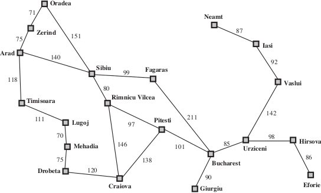

Quelle: [AIMA 3rd ed.](http://aima.cs.berkeley.edu)

Führen Sie eine Handsimulation der Breitensuche durch. Start ist “Sibiu”, Ziel ist “Pitesti”.

Geben Sie den Zustand der Queue in jedem Schritt an.

## Beispiele für mögliche Fragen (cnt.)

- Worin liegt der Unterschied zwischen einem Knoten und einem Zustand?
- Was ist ein Suchbaum? Wo liegt der Unterschied zum Zustandsraum?
- Muss der Suchbaum über eine eigene Datenstruktur realisiert werden?
- Was bedeutet Kantenkonsistenz?

## Beispiele für mögliche Fragen (cnt.)

Führen Sie den Perzeptron-Lernalgorithmus in Handsimulation durch. Lernen Sie die Boolesche Funktion OR. Die Trainingsmenge ist: …

Ihr Programm soll eine Tabelle mit den Spalten

> $w_1$, $w_2$, $-\theta$, $x_1$, $x_2$, $k$, $\sum_{i=1}^n w_i x_i - \theta$, Vorhersage, Änderung? (=,+,-)

ausgeben, die eine Zeile für jeden Lernschritt enthält. Geben Sie die vollständige Lerntabelle an.

Anders als in der Vorlesung besprochen, sollen die Gewichte $w_1$ und $w_2$ sowie die Schwelle $\theta$ jeweils mit dem Wert $0$ initialisiert werden. Die Lernschrittweite $\alpha$ sei $0.5$. Nutzen Sie die $\operatorname{sign}$-Funktion als Aktivierungsfunktion:
$$\operatorname{sign}(x) = \left\{
\begin{array}{ll}
0 & \text{falls } x<0\\
1 & \text{sonst}
\end{array}
\right.$$

Zeichnen Sie eine geometrische Interpretation Ihres Perzeptrons nach dem Lernen (Trennebene, Gewichtsvektor, Trainingsbeispiele).

## Beispiele für mögliche Fragen (cnt.)

Gegeben sei folgender Trainingsdatensatz …

Bauen Sie mit Hilfe von ID3 einen Entscheidungsbaum auf. Welches Attribut würde als erster Test verwendet werden und warum? Wie bestimmt sich die Reihenfolge der weiteren Attribute?

Als Hilfe gegeben: Einige wichtige Logarithmen zur Basis 2

## Beispiele für mögliche Fragen (cnt.)

Betrachten Sie das folgende Constraintproblem:

- $\mathrm{C}_1 = \{(a,b)\;|\;\; a \ne b\}$
- $\mathrm{C}_2 = \{(b,c)\;|\;\; b \ne c\}$
- $\mathrm{C}_3 = \{(a,c)\;|\;\; a = c\}$
- $D_a=D_b=D_c=\{1,2,3,4,5\}$, $D_d=\{1,2,5\}$, $D_e=\{1,3\}$

Zeichnen Sie den zugehörigen Constraintgraphen.

Zeigen Sie per Handsimulation, wie der Algorithmus AC-3 schrittweise Kantenkonsistenz herstellt.

## Beispiele für mögliche Fragen (cnt.)

In der Vorlesung wurde die Delta-Regel bzw. die Gewichtsupdates bei der Backpropagation für die Ausgabeschicht und die davor liegende letzte Hidden-Layer unter Verwendung der Transferfunktion $g(a) = 1/(1+\exp(-a))$ vorgerechnet.

Leiten Sie die Gewichtsupdates für die letzte und die vorletzte Schicht unter Verwendung der alternativen Transferfunktion $g(a) = \tanh(a)$ her.

[^1]: entfällt im WS 2017/18